# Introducing the ‘polmineR’-package

Andreas Blätte (andreas.blaette@uni-due.de)

2019-05-16

## Purpose

The purpose of the package *polmineR* is to offer a toolset for the interactive analysis of corpora using R. Apart from performance and usability, key considerations for developing the package are:

- To provide a library with standard tasks such as concordances/keyword-in-context, cooccurrence statistics, feature extraction, or preparation of term-document-matrics.
- To keep the original text accessible and to offer a seamless integration of qualitative and quantitative steps in corpus analysis that facilitates validation.
- To make the creation and analysis of subcorpora (‘partitions’) as easy as possible. A particular strength of the package is to support research on synchronic and diachronic change of language use.
- To offer performance for users with a standard infrastructure. The package is developed based on the idea of a three-tier software design. Corpus data are managed and indexed using the [Corpus Workbench (CWB)](http://cwb.sourceforge.net/), which serves as a backend.
- To support sharing consolidated and documented data, following the ideas of reproducible research.

The *polmineR* package supplements R packages that are already widely used for text mining. The [CRAN NLP task view](https://CRAN.R-project.org/view=NaturalLanguageProcessing) is a good place to learn about relevant packages. The *polmineR* package is intended to be an interface between the [Corpus Workbench (CWB)](http://cwb.sourceforge.net/), an efficient system for storing and querying large corpora, and existing packages for text mining and text statistics.

Apart from the speed of text processing, the Corpus Query Processor (CQP) and the [CQP syntax](http://cwb.sourceforge.net/files/CQP_Tutorial.pdf) provide a powerful and widely used syntax to query corpora. This is not an unique idea. Using a combination of R and the CWB implies a software architecture you will also find in the [TXM project](http://sourceforge.net/projects/txm/), or with [CQPweb](http://cwb.sourceforge.net/cqpweb.php). The *polmineR* package offers a library with the grammer of corpus analysis below a graphical user interface (GUI). It is a toolset to perform simple tasts efficiently as well as to implement complex workflows.

Advanced users will benefit from acquiring a good understanding of the Corpus Workbench. The [Corpus Encoding Tutorial](http://cwb.sourceforge.net/files/CWB_Encoding_Tutorial.pdf) is an authoritative text for that. [The vignette of the rcqp package](https://cran.r-project.org/src/contrib/Archive/rcqp/), albeit archived, includes an excellent explanation of the CWB data-model. The inferface used now to use CWB/CQP functionality is the [RcppCWB package](https://CRAN.R-project.org/package=RcppCWB).

A basic issue to understand is the difference between *s*- and *p*-attributes. The CWB distinguishes structural attributes (s-attributes) that will contain the metainformation that can be used to generate subcorpora/partitions, and positional attributes (p-attributes). Typically, the p-attributes will be ‘word’, ‘pos’ (for part-of-speech) and ‘lemma’ (for the lemmatized word form).

## Getting started

CRAN releases of *polmineR* can be installed with the usual call of `install.packages()`.

```r
install.packages("polmineR")
```

Binaries are available for Windows, and everything should work out of the box. On macOS and Linux, system requirements need to be fulfilled. The annex of the vignette includes a detailed explanation how to install *polmineR* on macOS, and Linux.

### Loading polmineR

The *polmineR* package is loaded just like any other package.

```r
library(polmineR)
```

Upon loading the package, the package version is reported. As *polmineR* is under active development, please check whether a more recent version is available at CRAN. Development versions are available at GitHub.

In addition, you will see an information on the *session registry*, which needs some further explanation.

### The session registry directory

Indexed corpus data may be stored at different locations on your machine. CWB users will usually have a data directory with subdirectories for every single corpus. But corpus data may also reside within R packages, or anywhere else.

It is not necessary to move indexed corpora to one single location. The only recommendation is to have them on a device that can be accessed sufficiently fast. Corpora are not fully loaded into memory, but information is retrieved from disk on a ‘on demand’-basis. Thus, storing corpus data on a SSD may be faster than a hard drive.

The CWB will look up information on the corpora in a directory called *registry* that is defined by the environment variable CORPUS_REGISTRY. Starting with version v0.7.9, the *polmineR* package creates a temporary registry directory in the temporary session directory. To get the path of the session registry directory, call `registry()`. The output is the session registry you have seen when loading *polmineR*.

```r
registry()
```

```
## [1] "/private/var/folders/m_/431fjnbs1t32_62d35wvs7pr0000gp/T/RtmpKPmgai/polmineR_registry"
```

The session registry directory combines the registry files describing the corpora *polmineR* knows about. Upon loading *polmineR*, the files in the registry directory defined by the environment variable CORPUS_REGISTRY are copied to the session registry directory. To see whether the environment variable CORPUS_REGISTRY is set, use the `Sys.getenv()`-function.

```r
Sys.getenv("CORPUS_REGISTRY")
```

See the annex for an explanation how to set the CORPUS_REGISTRY environment variable for the current R session, or permanently.

#### Using and installing packaged corpora

If you want to use a corpus wrapped into a R data package, call `use()` with the name of the R package. The function will add the registry files describing the corpora in the package to the session registry directory introduced before.

In the followings examples, the REUTERS corpus included in the *polmineR* package will be used for demonstration purposes. It is a sample of Reuters articles that is included in the tm package (cp. http://www.daviddlewis.com/resources/testcollections/reuters21578/), and may already be known to some R users.

```r
use("polmineR")
```

If you want to use corpora, you can download the EuroParl and the GermaParl data packages from a CRAN-like repository hosted by the PolMine Project.

```r
install.packages("europarl.en", repo = "http://polmine.sowi.uni-due.de/packages")
install.packages("GermaParl", repo = "http://polmine.sowi.uni-due.de/packages")
```

We some advantages to use R data packages for shipping corpora. Data packages with corpora have a version number which may be important for reproducing results, they can include a vignette documenting the data, and functions to perform specialized tasks.

#### Checking that corpora are available

The `corpus()`-method can be used to check which corpora are described in the registry and accessible. The REUTERS corpus in our case (note that the names of CWB corpora are always written upper case). In addition to the English REUTERS corpus, a small subset of the GermaParl corpus (“GERMAPARLMINI”) is included in the *polmineR* package.

```r
corpus()
```

```
##          corpus   size template
## 1 GERMAPARLMINI 222201     TRUE
## 2       REUTERS   4050     TRUE
```

#### Session settings

Many methods in the *polmineR* package use default settings that are set in the general options settings. Following a convention, settings relevant for the *polmineR* package simplystart with ‘polmineR.’ Inspect the settings as follows:

```r
options()[grep("polmineR", names(options()))]
```

Several methods (such as kwic, or cooccurrences) will use these settings, if no explicit other value is provided. You can see this in the usage section of help pages (`?kwic`, for instance). To change settings, this is how.

```r
options("polmineR.left" = 15)
options("polmineR.right" = 15)
options("polmineR.mc" = FALSE)
```

## Working with corpora: Core methods

Core analytical tasks are implemented as methods (S4 class system), i.e. the bevaviour of the methods changes depending on the object that is supplied. Almost all methods can be applied to corpora (indicated by a length-one character vector) as well as partitions (subcorpora). As a quick start, methods applied to corpora are explained first.

### Keyword-in-context (kwic)

The kwic method applied to the name of a corpus will return a KWIC object. Output will be shown in the viewer pane of RStudio. Technically, a htmlwidget is prepared which offers some convenient functionality.

```r
kwic("REUTERS", "oil")
```

|  | left | node | right |
| --- | --- | --- | --- |
| 1 | Shamrock Corp said that effective today it had cut its contract prices for crude | oil | by 1.50 dlrs a barrel The reduction brings its posted price for West Texas Intermediate |
| 2 | barrel the copany said The price reduction today was made in the light of falling | oil | product prices and a weak crude oil market a company spokeswoman said Diamond is the |
| 3 | today was made in the light of falling oil product prices and a weak crude | oil | market a company spokeswoman said Diamond is the latest in a line of U.S oil |
| 4 | oil market a company spokeswoman said Diamond is the latest in a line of U.S | oil | companies that have cut its contract or posted prices over the last two days citing |
| 5 | that have cut its contract or posted prices over the last two days citing weak | oil | markets Reuter OPEC may be forced to meet before a scheduled June session to readdress |
| 6 | readdress its production cutting agreement if the organization wants to halt the current slide in | oil | prices oil industry analysts said The movement to higher oil prices was never to be |
| 7 | production cutting agreement if the organization wants to halt the current slide in oil prices | oil | industry analysts said The movement to higher oil prices was never to be as easy |
| 8 | halt the current slide in oil prices oil industry analysts said The movement to higher | oil | prices was never to be as easy as OPEC thought They may need an emergency |
| 9 | out the problems said Daniel Yergin director of Cambridge Energy Research Associates CERA Analysts and | oil | industry sources said the problem OPEC faces is excess oil supply in world oil markets |
| 10 | Research Associates CERA Analysts and oil industry sources said the problem OPEC faces is excess | oil | supply in world oil markets OPEC's problem is not a price problem but a production |

[output cut: 68 more lines]

You can include metadata from the corpus into the kwic display using the ‘s_attributes’ argument. Let us start with one s-attribute.

```r
kwic("REUTERS", "oil", s_attributes = "places")
```

|  | places | left | node | right |
| --- | --- | --- | --- | --- |
| 1 | usa | Shamrock Corp said that effective today it had cut its contract prices for crude | oil | by 1.50 dlrs a barrel The reduction brings its posted price for West Texas Intermediate |
| 2 | usa | barrel the copany said The price reduction today was made in the light of falling | oil | product prices and a weak crude oil market a company spokeswoman said Diamond is the |
| 3 | usa | today was made in the light of falling oil product prices and a weak crude | oil | market a company spokeswoman said Diamond is the latest in a line of U.S oil |
| 4 | usa | oil market a company spokeswoman said Diamond is the latest in a line of U.S | oil | companies that have cut its contract or posted prices over the last two days citing |
| 5 | usa | that have cut its contract or posted prices over the last two days citing weak | oil | markets Reuter OPEC may be forced to meet before a scheduled June session to readdress |
| 6 | usa | readdress its production cutting agreement if the organization wants to halt the current slide in | oil | prices oil industry analysts said The movement to higher oil prices was never to be |
| 7 | usa | production cutting agreement if the organization wants to halt the current slide in oil prices | oil | industry analysts said The movement to higher oil prices was never to be as easy |
| 8 | usa | halt the current slide in oil prices oil industry analysts said The movement to higher | oil | prices was never to be as easy as OPEC thought They may need an emergency |
| 9 | usa | out the problems said Daniel Yergin director of Cambridge Energy Research Associates CERA Analysts and | oil | industry sources said the problem OPEC faces is excess oil supply in world oil markets |
| 10 | usa | Research Associates CERA Analysts and oil industry sources said the problem OPEC faces is excess | oil | supply in world oil markets OPEC's problem is not a price problem but a production |

[output cut: 68 more lines]

But you can display any number of s-attributes.

```r
kwic("REUTERS", "oil", s_attributes = c("id", "places"))
```

|  | id | places | left | node | right |
| --- | --- | --- | --- | --- | --- |
| 1 | 127 | usa | Shamrock Corp said that effective today it had cut its contract prices for crude | oil | by 1.50 dlrs a barrel The reduction brings its posted price for West Texas Intermediate |
| 2 | 127 | usa | barrel the copany said The price reduction today was made in the light of falling | oil | product prices and a weak crude oil market a company spokeswoman said Diamond is the |
| 3 | 127 | usa | today was made in the light of falling oil product prices and a weak crude | oil | market a company spokeswoman said Diamond is the latest in a line of U.S oil |
| 4 | 127 | usa | oil market a company spokeswoman said Diamond is the latest in a line of U.S | oil | companies that have cut its contract or posted prices over the last two days citing |
| 5 | 127 | usa | that have cut its contract or posted prices over the last two days citing weak | oil | markets Reuter OPEC may be forced to meet before a scheduled June session to readdress |
| 6 | 144 | usa | readdress its production cutting agreement if the organization wants to halt the current slide in | oil | prices oil industry analysts said The movement to higher oil prices was never to be |
| 7 | 144 | usa | production cutting agreement if the organization wants to halt the current slide in oil prices | oil | industry analysts said The movement to higher oil prices was never to be as easy |
| 8 | 144 | usa | halt the current slide in oil prices oil industry analysts said The movement to higher | oil | prices was never to be as easy as OPEC thought They may need an emergency |
| 9 | 144 | usa | out the problems said Daniel Yergin director of Cambridge Energy Research Associates CERA Analysts and | oil | industry sources said the problem OPEC faces is excess oil supply in world oil markets |
| 10 | 144 | usa | Research Associates CERA Analysts and oil industry sources said the problem OPEC faces is excess | oil | supply in world oil markets OPEC's problem is not a price problem but a production |

[output cut: 68 more lines]

You can also use the CQP query syntax for formulating queries. That way, you can find multi-word expressions, or match in a manner you may know from using regular expressions.

```r
kwic("REUTERS", '"oil" "price.*"')
```

|  | left | node | right |
| --- | --- | --- | --- |
| 1 | readdress its production cutting agreement if the organization wants to halt the current slide in | oil prices | oil industry analysts said The movement to higher oil prices was never to be as |
| 2 | halt the current slide in oil prices oil industry analysts said The movement to higher | oil prices | was never to be as easy as OPEC thought They may need an emergency meeting |
| 3 | outlook that the organization must address soon if it wishes to regain the initiative in | oil prices | But some other analysts were uncertain that even an emergency meeting would address the problem |
| 4 | plans for an emergency OPEC meeting to review oil policies after recent weakness in world | oil prices | Sheikh Ali al Khalifa al Sabah was quoted by the local daily al Qabas as |
| 5 | leading primary commodity producer has been severely hit by last year s fall in world | oil prices | which forced it to devalue its currency by 31 pct in September But the U.S |
| 6 | new positions amidst uncertainty over whether OPEC will succeed in halting the current decline in | oil prices | Oil industry sources said yesterday several Gulf Arab producers had had difficulty selling oil at |
| 7 | REUTER The Gulf oil state of Qatar recovering slightly from last year's decline in world | oil prices | announced its first budget since early 1985 and projected a deficit of 5.472 billion riyals |
| 8 | of 285,000 barrels per day Sheikh Abdul Aziz said Our expectations of positive signs regarding | oil price | trends foremost among them OPEC's determination to shoulder its responsibilites and protect its wealth have |
| 9 | Minister Hisham Nazer reiterated the kingdom's commitment to last December's OPEC accord to boost world | oil prices | and stabilise the market the official Saudi Press Agency SPA said Asked by the agency |
| 10 | Press Agency SPA said Asked by the agency about the recent fall in free market | oil prices | Nazer said Saudi Arabia is fully adhering by the Accord and it will never sell |

[output cut: 7 more lines]

Explaining the CQP syntax goes beyon this vignette. Consult the [CQP tutorial](http://cwb.sourceforge.net/files/CQP_Tutorial.pdf) to learn more about the CQP syntax.

### Getting counts and frequencies

You can count one or several hits in a corpus.

```r
count("REUTERS", "Kuwait")
```

```
##     query count        freq
## 1: Kuwait    15 0.003703704
```

```r
count("REUTERS", c("Kuwait", "USA", "Bahrain"))
```

```
##      query count         freq
## 1:  Kuwait    15 0.0037037037
## 2:     USA     0 0.0000000000
## 3: Bahrain     1 0.0002469136
```

```r
count("REUTERS", c('"United" "States"', '"Saudi" "Arabia.*"'), cqp = TRUE)
```

```
##                 query count         freq
## 1:  "United" "States"     2 0.0004938272
## 2: "Saudi" "Arabia.*"    12 0.0029629630
```

### Dispersions

Use the `dispersion()`-method to get dispersions of counts accross one (or two) dimensions.

```r
oil <- dispersion("REUTERS", query = "oil", sAttribute = "id", progress = FALSE)
saudi_arabia <- dispersion(
  "REUTERS", query = '"Saudi" "Arabia.*"',
  sAttribute = "id", cqp = TRUE, progress = FALSE
  )
```

Note that it is a data.table that is returned. You can proceed to a visualisation easily.

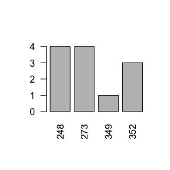

```r
barplot(height = saudi_arabia[["count"]], names.arg = saudi_arabia[["id"]], las = 2)
```

### Cooccurrences

To analyse the neighborhood of a token, or the match for a CQP query, use `cooccurrences()`.

```r
oil <- cooccurrences("REUTERS", query = "oil")
sa <- cooccurrences("REUTERS", query = '"Saudi" "Arabia.*"', left = 10, right = 10)
top5 <- subset(oil, rank_ll <= 5)
```

In an interactive session, simply type `top5` in the terminal, and the output will be shown in the data viewer. To inspect the output in the viewer pane, you can coerce the object to a htmlwidget. This is also a good way how to include the table in a Rmarkdown document.

```r
top5
```

| word | word_id | n_partition | n_coi | n_ref | exp_coi | exp_ref | ll | rank_ll |
| --- | --- | --- | --- | --- | --- | --- | --- | --- |
| is | 45 | 25 | 24 | 1 | 14.73 | 10.27 | 18.87 | 1 |
| by | 16 | 22 | 20 | 2 | 12.96 | 9.04 | 11.37 | 2 |
| it | 7 | 16 | 15 | 1 | 9.43 | 6.57 | 10.2 | 3 |
| said | 3 | 73 | 55 | 18 | 43.01 | 29.99 | 8.83 | 4 |
| production | 69 | 11 | 10 | 1 | 6.48 | 4.52 | 5.67 | 5 |

For further operations, get the the table with the statistical results by applying the `as.data.frame()`-method.

```r
as.data.frame(top5)
```

```
##         word word_id count_partition count_coi count_ref exp_coi exp_ref
## 1         is      45              25        24         1   14.73   10.27
## 2         by      16              22        20         2   12.96    9.04
## 3         it       7              16        15         1    9.43    6.57
## 4       said       3              73        55        18   43.01   29.99
## 5 production      69              11        10         1    6.48    4.52
##      ll rank_ll
## 1 18.87       1
## 2 11.37       2
## 3 10.20       3
## 4  8.83       4
## 5  5.67       5
```

## Working with subcorpora - partitions

```r
kuwait <- partition("REUTERS", places = "kuwait", regex = TRUE)
```

To get some basic information about the partition that has been set up, the ‘show’-method can be used. It is also called when you simply type the name of the partition object.

```r
kuwait
```

```
## ** partition object **
## corpus:              REUTERS
## name:
## s-attributes:        places = kuwait
## cpos:                3 pairs of corpus positions
## size:                660 tokens
## count:               not available
```

To evaluate s-attributes, regular expressions can be used.

```r
saudi_arabia <- partition("REUTERS", places = "saudi-arabia", regex = TRUE)
s_attributes(saudi_arabia, "id")
```

```
## [1] "242" "248" "273" "349" "352"
```

If you work with a flat XML structure, the order of the provided s-attributes may be relevant for speeding up the set up of the partition. For a nested XML, it is important that with the order, you move from ancestors to childs. For further information, see the documentation of the partition-function.

### Cooccurrences

The cooccurrences-method can be applied to partition-objects.

```r
saudi_arabia <- partition("REUTERS", places = "saudi-arabia", regex = TRUE)
oil <- cooccurrences(saudi_arabia, "oil", p_attribute = "word", left = 10, right = 10)
```

Note that is is possible to provide a query that uses the full CQP syntax. The statistical analysis of collocations to the query can be accessed as the slot “stat” of the context object. Alternatively, you can get the table with the statistics using ´as.data.frame´.

```r
df <- as.data.frame(oil)
df[1:5, c("word", "ll", "rank_ll")]
```

```
##     word       ll rank_ll
## 1 prices 5.383314       1
## 2     by 5.081723       2
## 3   Gulf 4.944806       3
## 4  crude 2.968707       4
## 5   last 2.756452       5
```

### Distribution of queries

```r
q1 <- dispersion(saudi_arabia, query = 'oil', s_attribute = "id", progress = FALSE)
q2 <- dispersion(saudi_arabia, query = c("oil", "barrel"), s_attribute = "id", progress = FALSE)
```

### Getting features

To identify the specific vocabulary of a corpus of interest, a statistical test based (chi square, or log likelihood) can be performed.

```r
saudi_arabia <- partition("REUTERS", places = "saudi-arabia", regex = TRUE)
saudi_arabia <- enrich(saudi_arabia, p_attribute = "word")

saudi_arabia_features <- features(saudi_arabia, "REUTERS", included = TRUE)
saudi_arabia_features_min <- subset(saudi_arabia_features, rank_chisquare <= 10.83 & count_coi >= 5)
as(round(saudi_arabia_features_min), "htmlwidget")
```

|  | word | n_coi | n_ref | exp_coi | chisquare | rank_chisquare |
| --- | --- | --- | --- | --- | --- | --- |
| 1 | Saudi | 18 | 0 | 4.84 | 49.22 | 1 |
| 2 | Nazer | 7 | 0 | 1.88 | 19.09 | 2 |
| 3 | accord | 7 | 0 | 1.88 | 19.09 | 3 |
| 4 | market | 14 | 6 | 5.37 | 19.03 | 4 |
| 5 | 8 | 6 | 0 | 1.61 | 16.36 | 5 |
| 6 | Arabia | 6 | 0 | 1.61 | 16.36 | 6 |
| 7 | sources | 7 | 2 | 2.42 | 11.9 | 7 |

To extract the statistical information, you can also use the `as.data.frame`-method.

```r
df <- as.data.frame(saudi_arabia_features_min)
df_min <- df[,c("word", "count_coi", "count_ref", "chisquare")]
```

### Getting a tm TermDocumentMatrix

For many applications, term-document matrices are the point of departure. The tm class TermDocumentMatrix serves as an input to several R packages implementing advanced text mining techniques. Obtaining this input from a corpus imported to the CWB will usually involve setting up a partitionBundle and then applying a method to get the matrix.

```r
articles <- partition_bundle("REUTERS", s_attribute = "id", progress = FALSE)
```

```
## ... getting matrix with regions for s-attribute:  id
```

```
## ... generating the partitions
```

```r
articles_count <- count(articles, p_attribute = "word")
tdm <- as.TermDocumentMatrix(articles_count, col = "count", verbose = FALSE)

class(tdm) # to see what it is
```

```
## [1] "TermDocumentMatrix"    "simple_triplet_matrix"
```

```r
show(tdm)
```

```
## <<TermDocumentMatrix (terms: 1192, documents: 20)>>
## Non-/sparse entries: 2409/21431
## Sparsity           : 90%
## Maximal term length: 15
## Weighting          : term frequency (tf)
```

```r
m <- as.matrix(tdm) # turn it into an ordinary matrix
m[c("oil", "barrel"),]
```

```
##         Docs
## Terms    127 144 191 194 211 236 237 242 246 248 273 349 352 353 368 489
##   oil      5  12   2   1   0   6   4   2   5   6   5   4   4   4   3   4
##   barrel   2   0   1   1   0   3   0   0   0   2   2   0   1   0   0   1
##         Docs
## Terms    502 543 704 708
##   oil      5   2   3   1
##   barrel   1   1   0   0
```

### Reading

A key consideration of the polmineR package is to offer tools for combining quantitative and qualitative approaches to text analysis. Use the `html()`-method, or the `read()`-method to return to the full text. In this example, we define a maximum height for the output, which is useful when including full text output in a Rmarkdown document.

```r
P <- partition("REUTERS", id = "248")
H <- html(P, height = "250px")
H
```

## Corpus: REUTERS

### id: 248

Saudi Arabian Oil Minister Hisham Nazer reiterated the kingdom's commitment to last December's OPEC accord to boost world oil prices and stabilise the market the official Saudi Press Agency SPA said Asked by the agency about the recent fall in free market oil prices Nazer said Saudi Arabia is fully adhering by the Accord and it will never sell its oil at prices below the pronounced prices under any circumstance Nazer quoted by SPA said recent pressure on free market prices may be because of the end of the northern hemisphere winter season and the glut in the market Saudi Arabia was a main architect of the December accord under which OPEC agreed to lower its total output ceiling by 7.25 pct to 15.8 mln barrels per day bpd and return to fixed prices of around 18 dlrs a barrel The agreement followed a year of turmoil on oil markets which saw prices slump briefly to under 10 dlrs a barrel in mid 1986 from about 30 dlrs in late 1985 Free market prices are currently just over 16 dlrs Nazer was quoted by the SPA as saying Saudi Arabia's adherence to the accord was shown clearly in the oil market He said contacts among members of OPEC showed they all wanted to stick to the accord In Jamaica OPEC President Rilwanu Lukman who is also Nigerian Oil Minister said the group planned to stick with the pricing agreement We are aware of the negative forces trying to manipulate the operations of the market but we are satisfied that the fundamentals exist for stable market conditions he said Kuwait's Oil Minister Sheikh Ali al Khalifa al Sabah said in remarks published in the emirate's daily Al Qabas there were no plans for an emergency OPEC meeting to review prices Traders and analysts in international oil markets estimate OPEC is producing up to one mln bpd above the 15.8 mln ceiling They named Kuwait and the United Arab Emirates along with the much smaller producer Ecuador among those producing above quota Sheikh Ali denied that Kuwait was over producing REUTER

## Moving on

The package includes many features that go beyond this vignette. It is a key aim in the project to develop respective documentation in the vignette and the man pages for the individual functions further. Feedback is very welcome!

## Annex I: Installing polmineR

### Windows

The following instructions assume that you have installed R. If not, install it from[CRAN](https://cran.r-project.org/bin/windows/base/). An installation of [RStudio](https://www.rstudio.com/products/rstudio/download/#download) is highly recommended.

#### Windows (32 and 64 bit)

Install *polmineR* and all dependencies the conventional way.

```r
install.packages("polmineR")
```

To install the most recent development version, hosted in a GitHub repository, use the convenient installation mechanism offered by the devtools package.

```r
install.packages("devtools")
devtools::install_github("PolMine/polmineR", ref = "dev")
```

Finally, as a basic test whether the REUTERS corpus included in the polmineR package (for testing and demonstration purposes) is available, run:

```r
use("polmineR")
corpus()
```

### macOS

The following instructions for Mac users assume that R is installed on your system. Binaries are available from the [Homepage of the R Project](https://cran.r-project.org/bin/macosx/). An installation of RStudio is highly recommended. Get the Open Source License version of [RStudio Desktop](https://www.rstudio.com/products/rstudio/download/).

##### Installing RcppCWB

To install polmineR on macOS, you first need to install RcppCWB.

First, you will need an installation of Xcode, which you can get it via the Mac App Store. You will also need the Command Line Tools for Xcode. It can be installed from a terminal with:

```bash
xcode-select --install
```

Please make sure that you agree to the license.

Second, an installation of XQuartz is required, it can be obtained from [www.xquartz.org](https://www.xquartz.org/).

Third, to compile the C code in the RcppCWB package, there are system requirements that need to be fulfilled. Using a package manager makes things considerably easier. We recommend using ‘Homebrew’. To install Homebrew, follow the instructions on the [Homebrew Homepage](https://brew.sh/index_de.html). The following commands then need to be executed from a terminal window. They will install the dependencies that the RcppCWB package relies on:

```bash
brew -v install pkg-config
brew -v install glib --universal
brew -v install pcre --universal
brew -v install readline
```

Fourth, install RcppCWB.

```r
install.packages("RcppCWB")
```

Now everything is ready to install polmineR.

```r
install.packages("polmineR")
```

A quick check that polmineR is installed correctly is to load the library, and to check which corpora are available.

```r
library(polmineR)
use("polmineR")
corpus()
```

The development version of *polmineR* can be installed using devtools:

```r
install.packages("devtools") # unless devtools is already installed
devtools::install_github("PolMine/polmineR", ref = "dev")
```

### Linux (Ubuntu)

#### Installing R

If you have not yet installed R on your Ubuntu machine, there is a good instruction at [ubuntuuser](https://wiki.ubuntuusers.de/R/). To install base R, enter in the terminal.

```bash
sudo apt-get install r-base r-recommended
```

Make sure that you have installed the latest version of R. The following commands will add the R repository to the package sources and run an update. The second line assumes that you are using Ubuntu 16.04.

```bash
sudo apt-key adv --recv-keys --keyserver keyserver.ubuntu.com E084DAB9
sudo add-apt-repository 'deb http://ftp5.gwdg.de/pub/misc/cran/bin/linux/ubuntu xenial/'
sudo apt-get update
sudo apt-get upgrade
```

#### Installing RStudio

It is highly recommended to install [RStudio](https://www.rstudio.com/products/rstudio/download/#download). Output of polmineR methods is generally optimized to be displayed using RStudio facilities. If you are working on a remote server, running RStudio Server may be an interesting option to consider.

#### Base Installation of polmineR

The Corpus Workbench will require the pcre, glib and pkg-config libraries. They can be installed as follows. In addition libxml2 is installed, a dependency of the R package xml2 that is used for manipulating html output.

```bash
sudo apt-get install libglib2.0-dev libssl-dev libcurl4-openssl-dev
sudo apt-get install libxml2-dev
sudo apt-get install libprotobuf-dev
```

The system requirements will now be fulfilled. From R, install dependencies for rcqp/polmineR first, and then rcqp and polmineR.

```r
install.packages("RcppCWB")
install.packages("polmineR")
```

Use devtools to install the development version of polmineR from GitHub.

```r
install.packages("devtools")
devtools::install_github("PolMine/polmineR", ref = "dev")
```

Finally, check the installation.

```r
library(polmineR)
use("polmineR")
corpus()
```

#### Annex II: Setting the CORPUS_REGISTRY environment variable

The environment variable “CORPUS_REGISTRY” can be set as follows in R:

```r
Sys.setenv(CORPUS_REGISTRY = "C:/PATH/TO/YOUR/REGISTRY")
```

To set the environment variable CORPUS_REGISTRY permanently, see the instructions R offer how to find the file ‘.Renviron’ or ‘.Renviron.site’ when calling the help for the startup process(`?Startup`).